# Day 1: Shrinkage Methods–Lasso and Ridge Regression

Emilio Lehoucq

2020-08-21

This session will cover how to implement shrinkage methods, specifically Lasso and Ridge regression, in R. Shrinkage methods are useful when the relation between the predictors and the response is linear and there are lots of predictors. If there are few predictors, you can use OLS or logistic regression or other techniques for variable selection such as best subsets or stepwise selection. Shrinkage methods address the issue, avoid multicolinearity, and they are regularized to avoid overfitting.

# Packages

These are the packages we’re going to use throughout the session:

```r
library(tidyverse)
library(janitor) # clean_names
library(robustHD) # standardize
library(skimr) # descriptive statistics
library(ggcorrplot) # correlation matrix
library(glmnet) # shrinkage methods
library(glmnetUtils) # improves glmnet
```

# Data

We’re going to use the [Online News Popularity Data Set](https://archive.ics.uci.edu/ml/datasets/Online+News+Popularity) from the UCI Machine Learning Repository. The target is the number of shares (`shares`). Here I’m dealing with quick data wrangling to get the data ready for modeling.

Keep in mind it’s best to standardize your numerical predictors before fitting Lasso and Ridge models.

```r
set.seed(1) # to ensure replicability every time there's randomization

factors <- c("data_channel_is_lifestyle", "data_channel_is_entertainment", "data_channel_is_bus",
             "data_channel_is_socmed", "data_channel_is_tech", "data_channel_is_world",
             "weekday_is_monday", "weekday_is_tuesday", "weekday_is_wednesday",
             "weekday_is_thursday", "weekday_is_friday", "weekday_is_saturday",
             "weekday_is_sunday", "is_weekend") # all factors in the dataset

news <- read_csv(here::here("data/OnlineNewsPopularity.csv")) %>%
  sample_n(., 1500) %>% # we're only going to use 1,500 observations to run models faster during the sessions
  clean_names() %>% # to have all column names lower case letters
  select(-c(url, lda_00:lda_04)) %>% # we don't want these predictors
  mutate_each_(funs(factor(.)), factors) %>% # converting to factors
  mutate(log_shares = log(shares)) %>% # taking the log of our response
  select(-shares) %>%  # droping the original response
  mutate_if(is.numeric, funs(standardize(.))) # standardizing numeric variables
```

In statistical learning/predictive modeling, you don’t care about how your model performs in the data you have at hand, but how it would perform either in the population or in new data that comes your way. Of course, you don’t have these data. Cross validation is a set of resampling methods to address this problem. It allows you to estimate your test error. It’s important to not use the same set of data for model tuning and for model validation. There are three main types of cross validation: validation set approach, leave one out cross validation, and k-fold cross validation. K-fold cross validation (where usually k=10, 5 or 3, depending on data/computing power) is the ideal. Also, since cross validation involves randomization, it’ll give different results across iterations. Ideally, you can do several and average across them.

We’re going to cover the validation set approach and k-fold cross validation over these three days.

Today, we’re going to use k-fold cross validation for model tuning and the validation set approach for model validation. Now, we’re going to split the dataset into two for tuning and validation:

```r
set.seed(1)

news_train <- news %>% sample_frac(0.7)
news_test <- news %>% setdiff(news_train)
```

# Exploratory data analysis

Before modeling, you should always conduct an exploratory data analysis. During these three days, we’ll only do one today and it’ll be very brief.

Let’s first take a look at some descriptives.

```r
skim(news_train)
```

```
## Skim summary statistics
##  n obs: 1050
##  n variables: 55
##
## ── Variable type:factor ──────────────────────────────────────────────────────────────────────────────────────────────────────────────────────────────────────
##                       variable missing complete    n n_unique
##            data_channel_is_bus       0     1050 1050        2
##  data_channel_is_entertainment       0     1050 1050        2
##      data_channel_is_lifestyle       0     1050 1050        2
##         data_channel_is_socmed       0     1050 1050        2
##           data_channel_is_tech       0     1050 1050        2
##          data_channel_is_world       0     1050 1050        2
##                     is_weekend       0     1050 1050        2
##              weekday_is_friday       0     1050 1050        2
##              weekday_is_monday       0     1050 1050        2
##            weekday_is_saturday       0     1050 1050        2
##              weekday_is_sunday       0     1050 1050        2
##            weekday_is_thursday       0     1050 1050        2
##             weekday_is_tuesday       0     1050 1050        2
##           weekday_is_wednesday       0     1050 1050        2
##             top_counts ordered
##  0: 904, 1: 146, NA: 0   FALSE
##  0: 863, 1: 187, NA: 0   FALSE
##  0: 1005, 1: 45, NA: 0   FALSE
##   0: 993, 1: 57, NA: 0   FALSE
##  0: 862, 1: 188, NA: 0   FALSE
##  0: 800, 1: 250, NA: 0   FALSE
##  0: 918, 1: 132, NA: 0   FALSE
##  0: 894, 1: 156, NA: 0   FALSE
##  0: 861, 1: 189, NA: 0   FALSE
##   0: 988, 1: 62, NA: 0   FALSE
##   0: 980, 1: 70, NA: 0   FALSE
##  0: 858, 1: 192, NA: 0   FALSE
##  0: 873, 1: 177, NA: 0   FALSE
##  0: 846, 1: 204, NA: 0   FALSE
##
## ── Variable type:numeric ─────────────────────────────────────────────────────────────────────────────────────────────────────────────────────────────────────
##                      variable missing complete    n     mean   sd    p0
##  abs_title_sentiment_polarity       0     1050 1050  0.0085  1.01 -0.71
##        abs_title_subjectivity       0     1050 1050 -0.0027  1    -1.81
```

[output cut: 66 more lines]

```
##  -0.67  -0.2     0.73    3.54 ▁▂▆▇▃▃▁▁
##  -0.45   0.078   0.55    2.65 ▁▁▁▃▇▇▂▁
##  -0.62  -0.27    0.25    9.47 ▇▂▁▁▁▁▁▁
##  -0.42  -0.42   -0.083  11.58 ▇▁▁▁▁▁▁▁
##  -0.67  -0.14    0.91    1.43 ▁▁▂▃▅▃▃▇
##  -0.63  -0.08    0.19    8.66 ▇▂▁▁▁▁▁▁
##  -0.3   -0.3    -0.084  15.6  ▇▁▁▁▁▁▁▁
##  -0.68  -0.02    0.67    4.52 ▅▇▇▆▂▁▁▁
##  -0.51   0.11    0.61    1.69 ▁▁▁▂▅▇▇▃
##  -0.32  -0.23   -0.047  12.87 ▇▁▁▁▁▁▁▁
##  -0.3   -0.22   -0.023   7.61 ▇▁▁▁▁▁▁▁
##  -0.26  -0.21   -0.082  15.4  ▇▁▁▁▁▁▁▁
##  -0.82  -0.042   0.92    1.74 ▇▇▇▆▆▆▆▇
##  -0.27  -0.27    0.31    3.55 ▁▁▁▁▇▂▁▁
##  -0.88  -0.4     0.62    2.13 ▇▁▁▃▁▁▁▂
```

Two noticeable things for us: - there are no missing values - our response (log_shares) seems reasonably close to a Normal distribution

We could do a correlation matrix, why not?

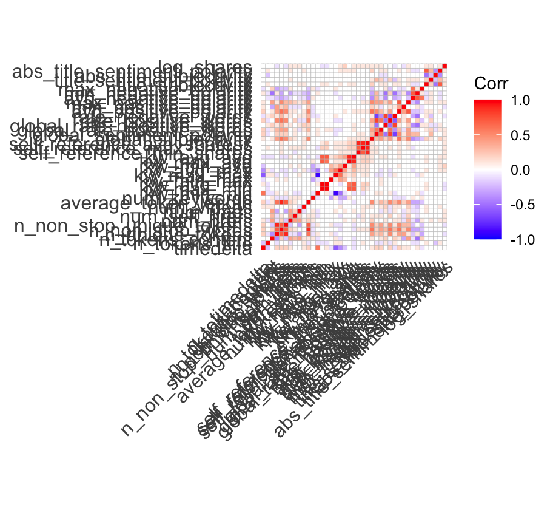

```r
corr <- round(cor(news_train %>%select_if(is.numeric)), 1)

ggcorrplot(corr, lab = FALSE)
```

Of course, there are many other things you should do in an exploratory data analysis. We’re going to skip that here for time purposes. We’ll focus on the models.

# OLS regression

Don’t jump into the “fancy model hype.” Plain old vanilla OLS and logistic regressions get you very far, particularly when the relation between the predictors and the response is linear. You should always fit different models and compare their performance on the test set.

Let’s try a kitchen sink OLS. We’ll compare the performance of our shrinkage models with it.

```r
kitchen_sink <- lm(log_shares ~ ., news_train)

summary(kitchen_sink)
```

```
##
## Call:
## lm(formula = log_shares ~ ., data = news_train)
##
## Residuals:
##     Min      1Q  Median      3Q     Max
## -2.9917 -0.5992 -0.1505  0.3978  3.8638
##
## Coefficients: (3 not defined because of singularities)
##                                 Estimate Std. Error t value Pr(>|t|)
## (Intercept)                     0.365291   0.144128   2.534 0.011413 *
## timedelta                       0.064997   0.043197   1.505 0.132730
## n_tokens_title                  0.042353   0.031877   1.329 0.184274
## n_tokens_content               -0.057753   0.056066  -1.030 0.303224
## n_unique_tokens                -0.045732   0.131894  -0.347 0.728862
## n_non_stop_words               -0.071173   0.132631  -0.537 0.591646
## n_non_stop_unique_tokens       -0.107320   0.123872  -0.866 0.386489
## num_hrefs                       0.062650   0.038802   1.615 0.106709
## num_self_hrefs                  0.030240   0.038799   0.779 0.435923
## num_imgs                        0.010215   0.038465   0.266 0.790630
## num_videos                     -0.022488   0.030970  -0.726 0.467944
## average_token_length            0.097372   0.102858   0.947 0.344042
## num_keywords                   -0.005878   0.035621  -0.165 0.868957
## data_channel_is_lifestyle1     -0.064192   0.175796  -0.365 0.715074
## data_channel_is_entertainment1 -0.252076   0.123412  -2.043 0.041359 *
## data_channel_is_bus1           -0.036649   0.133913  -0.274 0.784386
## data_channel_is_socmed1         0.415846   0.165656   2.510 0.012220 *
## data_channel_is_tech1           0.189438   0.132896   1.425 0.154336
## data_channel_is_world1         -0.214107   0.143131  -1.496 0.135002
## kw_min_min                      0.056644   0.056863   0.996 0.319416
## kw_max_min                     -0.134857   0.153116  -0.881 0.378665
## kw_avg_min                     -0.080126   0.154979  -0.517 0.605262
## kw_min_max                     -0.038202   0.030105  -1.269 0.204758
## kw_max_max                      0.063055   0.065393   0.964 0.335154
## kw_avg_max                     -0.004582   0.054696  -0.084 0.933256
## kw_min_avg                     -0.003520   0.042786  -0.082 0.934455
## kw_max_avg                     -0.348027   0.088413  -3.936 8.85e-05 ***
## kw_avg_avg                      0.539342   0.112298   4.803 1.80e-06 ***
## self_reference_min_shares      -0.257036   0.167756  -1.532 0.125790
## self_reference_max_shares      -0.455266   0.219854  -2.071 0.038637 *
```

[output cut: 16 more lines]

```
## min_positive_polarity          -0.074929   0.044049  -1.701 0.089247 .
## max_positive_polarity          -0.029114   0.053078  -0.549 0.583461
## avg_negative_polarity           0.021283   0.082713   0.257 0.796990
## min_negative_polarity          -0.045685   0.069222  -0.660 0.509424
## max_negative_polarity          -0.013731   0.051910  -0.265 0.791440
## title_subjectivity              0.033375   0.045340   0.736 0.461844
## title_sentiment_polarity        0.008143   0.032493   0.251 0.802177
## abs_title_subjectivity         -0.009329   0.034878  -0.267 0.789163
## abs_title_sentiment_polarity    0.003014   0.045283   0.067 0.946954
## ---
## Signif. codes:  0 '***' 0.001 '**' 0.01 '*' 0.05 '.' 0.1 ' ' 1
##
## Residual standard error: 0.9375 on 998 degrees of freedom
## Multiple R-squared:  0.2036, Adjusted R-squared:  0.1629
## F-statistic: 5.004 on 51 and 998 DF,  p-value: < 2.2e-16
```

Well, we’re not getting a lot of traction to decide on news articles’ postings… Let’s see if we can do better.

This model could have issues of variable selection, multicollinearity, and non-linearities.

# Ridge regression

Ridge regression penalizes the size of the coefficients such that it shrinks them toward zero, but without reaching zero. It doesn’t perform variable selection, then.

```r
set.seed(1)

lambda_grid <- 10^seq(-2, 10, length = 200)

ridge_cv <- cv.glmnet(formula = log_shares ~ .,
                      data = news_train,
                      alpha = 0, # Ridge!
                      nfolds = 10,
                      lambda = lambda_grid
    )
```

Let’s make sure we tuned the model correctly.

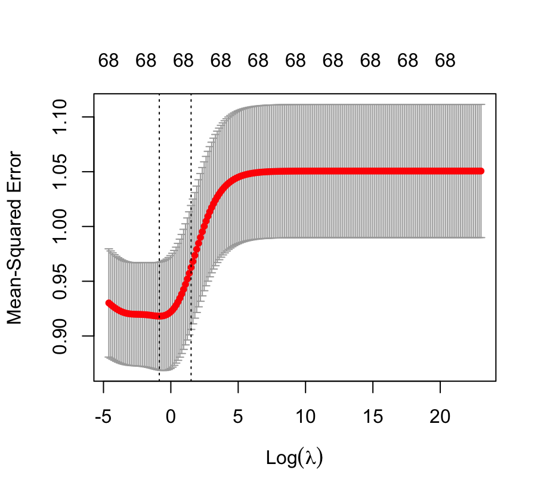

```r
plot(ridge_cv)
```

This looks good–the test error is decreasing, reaching a minima, and then increasing again.

There are two conventional options for selecting the “best” model–selecting the regualization parameter to minimize the error or to have it one standard error above the minimum.

```r
ridge_lambda_min <- ridge_cv$lambda.min
ridge_lambda_1se <- ridge_cv$lambda.1se

ridge_min <- glmnet(log_shares ~ ., data = news_train, alpha = 0, lambda = ridge_lambda_min)
ridge_1se <- glmnet(log_shares ~ ., data = news_train, alpha = 0, lambda = ridge_lambda_1se)

coef(ridge_min)
```

```
## 69 x 1 sparse Matrix of class "dgCMatrix"
##                                           s0
## (Intercept)                     0.0295826517
## timedelta                       0.0287198215
## n_tokens_title                  0.0118963482
## n_tokens_content               -0.0299471624
## n_unique_tokens                -0.0278079105
## n_non_stop_words               -0.0148918861
## n_non_stop_unique_tokens       -0.0585799480
## num_hrefs                       0.0591623800
## num_self_hrefs                 -0.0001557748
## num_imgs                        0.0296380892
## num_videos                     -0.0117986359
## average_token_length            0.0009212036
## num_keywords                    0.0121991566
## data_channel_is_lifestyle0      0.0302886943
## data_channel_is_lifestyle1     -0.0302276385
## data_channel_is_entertainment0  0.1445905505
## data_channel_is_entertainment1 -0.1445286143
## data_channel_is_bus0            0.0683022803
## data_channel_is_bus1           -0.0682231686
## data_channel_is_socmed0        -0.1648619300
## data_channel_is_socmed1         0.1649236719
## data_channel_is_tech0          -0.0359149828
## data_channel_is_tech1           0.0359907517
## data_channel_is_world0          0.1593922763
## data_channel_is_world1         -0.1592442817
## kw_min_min                      0.0218178732
## kw_max_min                     -0.0527033583
## kw_avg_min                     -0.0337906441
## kw_min_max                     -0.0226513121
## kw_max_max                      0.0206404739
## kw_avg_max                      0.0423507986
## kw_min_avg                      0.0659875663
## kw_max_avg                     -0.0275811952
## kw_avg_avg                      0.0991107031
## self_reference_min_shares       0.0458299249
## self_reference_max_shares       0.0099246991
## self_reference_avg_sharess      0.0510527989
## weekday_is_monday0             -0.0457192427
```

[output cut: 16 more lines]

```
## global_sentiment_polarity      -0.0032665692
## global_rate_positive_words      0.0204784524
## global_rate_negative_words      0.0066272244
## rate_positive_words            -0.0037395543
## rate_negative_words            -0.0098593272
## avg_positive_polarity           0.0029064525
## min_positive_polarity          -0.0448055825
## max_positive_polarity           0.0024757526
## avg_negative_polarity          -0.0110952527
## min_negative_polarity          -0.0166697449
## max_negative_polarity          -0.0018900107
## title_subjectivity              0.0221499928
## title_sentiment_polarity        0.0094486075
## abs_title_subjectivity         -0.0101181252
## abs_title_sentiment_polarity    0.0204796449
```

```r
cbind(ridge_min$dev.ratio, ridge_1se$dev.ratio)
```

```
##           [,1]       [,2]
## [1,] 0.1761344 0.09960331
```

## Classification

For classification, you need to set `family` to `"binomial"`. Otherwise, the code stays the same.

# Lasso regression

Lasso regression penalizes the size of the coefficients such that it shrinks them toward zero and some to zero. It performs variable selection, then.

```r
set.seed(1)

lasso_cv <- cv.glmnet(formula = log_shares ~ .,
                      data = news_train,
                      alpha = 1, # Lasso!
                      nfolds = 10,
                      lambda = lambda_grid
    )
```

Let’s make sure we tuned the model correctly.

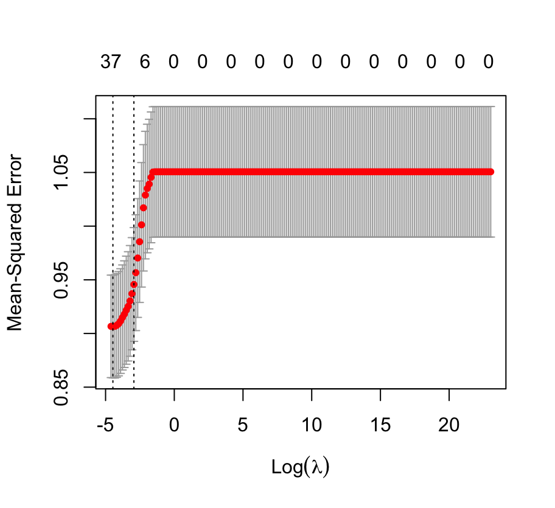

```r
plot(lasso_cv)
```

Again, it looks good–we seem to have reached a minima.

Two conventional options for the “best” model:

```r
lasso_lambda_min <- lasso_cv$lambda.min
lasso_lambda_1se <- lasso_cv$lambda.1se

lasso_min <- glmnet(log_shares ~ ., data = news_train, alpha = 1, lambda = lasso_lambda_min)
lasso_1se <- glmnet(log_shares ~ ., data = news_train, alpha = 1, lambda = lasso_lambda_1se)

coef(lasso_min)
```

```
## 69 x 1 sparse Matrix of class "dgCMatrix"
##                                           s0
## (Intercept)                     1.822846e-02
## timedelta                       2.808442e-02
## n_tokens_title                  1.335975e-02
## n_tokens_content               -1.836870e-02
## n_unique_tokens                 .
## n_non_stop_words                .
## n_non_stop_unique_tokens       -1.026395e-01
## num_hrefs                       6.342143e-02
## num_self_hrefs                  .
## num_imgs                        1.117103e-02
## num_videos                     -1.150172e-03
## average_token_length            .
## num_keywords                    .
## data_channel_is_lifestyle0      1.156252e-02
## data_channel_is_lifestyle1      .
## data_channel_is_entertainment0  2.742927e-01
## data_channel_is_entertainment1  .
## data_channel_is_bus0            4.692672e-02
## data_channel_is_bus1            .
## data_channel_is_socmed0        -3.572635e-01
## data_channel_is_socmed1         .
## data_channel_is_tech0          -1.212660e-01
## data_channel_is_tech1           1.116321e-13
## data_channel_is_world0          2.505996e-01
## data_channel_is_world1         -6.926204e-13
## kw_min_min                      .
## kw_max_min                     -1.694140e-01
## kw_avg_min                      .
## kw_min_max                     -2.306717e-02
## kw_max_max                      .
## kw_avg_max                      .
## kw_min_avg                      1.697306e-02
## kw_max_avg                     -2.113948e-01
## kw_avg_avg                      3.762536e-01
## self_reference_min_shares       4.548210e-02
## self_reference_max_shares       .
## self_reference_avg_sharess      5.290787e-02
## weekday_is_monday0             -5.717470e-02
```

[output cut: 16 more lines]

```
## global_sentiment_polarity       .
## global_rate_positive_words      1.338367e-02
## global_rate_negative_words      .
## rate_positive_words             .
## rate_negative_words             .
## avg_positive_polarity           .
## min_positive_polarity          -5.257052e-02
## max_positive_polarity           .
## avg_negative_polarity          -8.759608e-03
## min_negative_polarity          -7.377144e-03
## max_negative_polarity           .
## title_subjectivity              3.278482e-02
## title_sentiment_polarity        1.708011e-03
## abs_title_subjectivity         -6.325763e-04
## abs_title_sentiment_polarity    1.006794e-02
```

You can see it performs variable selection. Some coefficients are shrunk to zero.

```r
cbind(lasso_min$dev.ratio, lasso_1se$dev.ratio)
```

```
##           [,1]      [,2]
## [1,] 0.1913879 0.1342655
```

## Classification

For classification, you need to set `family` to `"binomial"`. Otherwise the code stays the same.

# Model validation

Remember you have to validate your models on the test data, This is where you compare their performance and select the “best” one.

A little helper function to get the $R^2$:

```r
# helper function
#' @name r2
#' @param model model
#' @param test test data
#' @param outcome string with the response
#' @returns test R2
r2<- function(model, test, outcome){

  preds <- predict(model, test)

  sse <- sum((test[[outcome]] - preds)^2)
  sst <- sum((test[[outcome]] - mean(test[[outcome]]))^2)
  r2 <- 1 - sse / sst

  return(r2)

}
```

## OLS regression

```r
kitchen_sink_test <- lm(log_shares ~ ., news_train)

r2(kitchen_sink_test, news_test, "log_shares")
```

```
## [1] 0.109881
```

## Ridge regression

```r
ridge_min_test <- glmnet(log_shares ~ ., data = news_train, alpha = 0, lambda = ridge_lambda_min)
ridge_1se_test <- glmnet(log_shares ~ ., data = news_train, alpha = 0, lambda = ridge_lambda_1se)

cbind(r2(ridge_min_test, news_test, "log_shares"), r2(ridge_1se_test, news_test, "log_shares"))
```

```
##           [,1]       [,2]
## [1,] 0.1049323 0.08072025
```

## Lasso regression

```r
lasso_min_test <- glmnet(log_shares ~ ., data = news_train, alpha = 1, lambda = lasso_lambda_min)
lasso_1se_test <- glmnet(log_shares ~ ., data = news_train, alpha = 1, lambda = lasso_lambda_1se)

cbind(r2(ridge_min_test, news_test, "log_shares"), r2(ridge_1se_test, news_test, "log_shares"))
```

```
##           [,1]       [,2]
## [1,] 0.1049323 0.08072025
```

They all perform pretty much the same. Also, they all perform noticeable worse on the test data–this is typically the case, because of overfitting.